# FIFA Analytics

Autors: * Rodrigo Rico * Roger Cervantes

```r
# Cargamos las librerías necesarias:
library(dplyr)
library(kableExtra)
library(GGally)

library(corrplot)

library(stringr)
library(gridExtra)
library(ggplot2)
library(DMwR)
library(caret)
library(ResourceSelection)
library(pROC)

library(magrittr)
library(maps)
library(plotly)
library(DT)
library(factoextra)
library(tidyr)
library(tibble)
```

```r
# Creamos una serie de funciones para mejorar la visualización
my.head <- function(x, num=6){
  head(x, num) %>%
    kable() %>%
    kable_styling(bootstrap_options = c("striped", "condensed", "hover")) %>%
    scroll_box(width="100%",height="264px") # 72 + 32*rows
}

my.kable <- function(x){
  x %>%
    kable() %>%
    kable_styling(bootstrap_options = c("striped", "condensed", "hover")) %>%
    scroll_box(width="100%",height="264px") # 72 + 32*rows
}

my.summary <- function(x){
  summary(x) %>%
    kable() %>%
    kable_styling(bootstrap_options = c("striped", "condensed", "hover")) %>%
    scroll_box(width="100%",height=72 + 32*7)
}

# Creamos la lista de variables segun tipo
#fifa.var_cuanti <- unlist(lapply(fifa, is.numeric))
#fifa.var_cuali <- unlist(lapply(fifa, is.factor))
```

# 1 Lectura del fichero

```r
# Leemos los ficheros
players_15 <- read.csv("Data/players_15.csv", sep=",", header=TRUE)
players_16 <- read.csv("Data/players_16.csv", sep=",", header=TRUE)
players_17 <- read.csv("Data/players_17.csv", sep=",", header=TRUE)
players_18 <- read.csv("Data/players_18.csv", sep=",", header=TRUE)
players_19 <- read.csv("Data/players_19.csv", sep=",", header=TRUE)
players_20 <- read.csv("Data/players_20.csv", sep=",", header=TRUE)

# Añadimos el año
players_15$year = as.integer(2015)
players_16$year = as.integer(2016)
players_17$year = as.integer(2017)
players_18$year = as.integer(2018)
players_19$year = as.integer(2019)
players_20$year = as.integer(2020)

# Los juntamos todos
fifa <- rbind(players_15, players_16, players_17, players_18, players_19, players_20)

# Limpiamos memoria
rm(players_15, players_16, players_17, players_18, players_19, players_20)

# Hacemos una primera visualización
my.head(fifa)
```

| sofifa_id | player_url | short_name | long_name | age | dob | height_cm | weight_kg | nationality | club | overall | potential | value_eur | wage_eur | player_positions | preferred_foot | international_reputation | weak_foot | skill_moves | work_rate | body_type | real_face | release_clause_eur | player_tags | team_position | team_jersey_number | loaned_from | joined | contract_valid_until | nation_position | … |
| --- | --- | --- | --- | --- | --- | --- | --- | --- | --- | --- | --- | --- | --- | --- | --- | --- | --- | --- | --- | --- | --- | --- | --- | --- | --- | --- | --- | --- | --- | --- |
| 158023 | https://sofifa.com/player/158023/lionel-messi/15/157759 | L. Messi | Lionel Andrés Messi Cuccittini | 27 | 1987-06-24 | 169 | 67 | Argentina | FC Barcelona | 93 | 95 | 0 | 0 | CF | Left | 5 | 3 | 4 | Medium/Low | Normal | Yes | NA | #Speedster, #Dribbler, #FK Specialist, #Acrobat, #Clinical Finisher, #Complete Forward | CF | 10 |  | 2004-07-01 | 2018 | CF | … |
| 20801 | https://sofifa.com/player/20801/c-ronaldo-dos-santos-aveiro/15/157759 | Cristiano Ronaldo | Cristiano Ronaldo dos Santos Aveiro | 29 | 1985-02-05 | 185 | 80 | Portugal | Real Madrid | 92 | 92 | 0 | 0 | LW, LM | Right | 5 | 4 | 5 | High/Low | Normal | Yes | NA | #Speedster, #Dribbler, #Distance Shooter, #Acrobat, #Clinical Finisher, #Complete Forward | LW | 7 |  | 2009-07-01 | 2018 | LW | … |
| 9014 | https://sofifa.com/player/9014/arjen-robben/15/157759 | A. Robben | Arjen Robben | 30 | 1984-01-23 | 180 | 80 | Netherlands | FC Bayern München | 90 | 90 | 0 | 0 | RM, LM, RW | Left | 5 | 2 | 4 | High/Low | Normal | Yes | NA | #Speedster, #Dribbler, #Distance Shooter, #Acrobat | SUB | 10 |  | 2009-08-28 | 2017 | RS | … |
| 41236 | https://sofifa.com/player/41236/zlatan-ibrahimovic/15/157759 | Z. IbrahimoviÄ‡ | Zlatan IbrahimoviÄ‡ | 32 | 1981-10-03 | 195 | 95 | Sweden | Paris Saint-Germain | 90 | 90 | 0 | 0 | ST | Right | 5 | 4 | 4 | Medium/Low | Normal | Yes | NA | #Poacher, #Aerial Threat, #Distance Shooter, #Acrobat, #Strength, #Clinical Finisher, #Complete Forward | ST | 10 |  | 2012-07-01 | 2016 | ST | … |
| 167495 | https://sofifa.com/player/167495/manuel-neuer/15/157759 | M. Neuer | Manuel Neuer | 28 | 1986-03-27 | 193 | 92 | Germany | FC Bayern München | 90 | 90 | 0 | 0 | GK | Right | 5 | 4 | 1 | Medium/Medium | Normal | Yes | NA |  | GK | 1 |  | 2011-07-01 | 2019 | GK | … |
| 176580 | https://sofifa.com/player/176580/luis-suarez/15/157759 | L. Suárez | Luis Alberto Suárez Díaz | 27 | 1987-01-24 | 181 | 81 | Uruguay | FC Barcelona | 89 | 91 | 0 | 0 | ST, CF | Right | 5 | 4 | 4 | High/Medium | Normal | Yes | NA | #Acrobat, #Clinical Finisher | RES | 9 |  | 2014-07-11 | 2019 |  | … |

```r
# Analizamos la estructura de las variables
str(fifa)
```

```
## 'data.frame':    100995 obs. of  105 variables:
##  $ sofifa_id                 : int  158023 20801 9014 41236 167495 176580 183277 7826 121944 156616 ...
##  $ player_url                : chr  "https://sofifa.com/player/158023/lionel-messi/15/157759" "https://sofifa.com/player/20801/c-ronaldo-dos-santos-aveiro/15/157759" "https://sofifa.com/player/9014/arjen-robben/15/157759" "https://sofifa.com/player/41236/zlatan-ibrahimovic/15/157759" ...
##  $ short_name                : chr  "L. Messi" "Cristiano Ronaldo" "A. Robben" "Z. IbrahimoviÄ‡" ...
##  $ long_name                 : chr  "Lionel AndrÃ©s Messi Cuccittini" "Cristiano Ronaldo dos Santos Aveiro" "Arjen Robben" "Zlatan IbrahimoviÄ‡" ...
##  $ age                       : int  27 29 30 32 28 27 23 30 29 31 ...
##  $ dob                       : chr  "1987-06-24" "1985-02-05" "1984-01-23" "1981-10-03" ...
##  $ height_cm                 : int  169 185 180 195 193 181 173 187 183 170 ...
##  $ weight_kg                 : int  67 80 80 95 92 81 74 71 79 72 ...
##  $ nationality               : chr  "Argentina" "Portugal" "Netherlands" "Sweden" ...
##  $ club                      : chr  "FC Barcelona" "Real Madrid" "FC Bayern MÃ¼nchen" "Paris Saint-Germain" ...
##  $ overall                   : int  93 92 90 90 90 89 88 88 88 88 ...
##  $ potential                 : int  95 92 90 90 90 91 90 88 88 88 ...
##  $ value_eur                 : int  0 0 0 0 0 0 0 0 0 0 ...
##  $ wage_eur                  : int  0 0 0 0 0 0 0 0 0 0 ...
```

[output cut: 86 more lines]

## 1.1 Selección de registros

```r
# Vamos a analizar solo algunas ligas

bundesliga <- c(
  "1. FC Nürnberg", "1. FSV Mainz 05", "Bayer 04 Leverkusen", "FC Bayern München",
  "Borussia Dortmund", "Borussia Mönchengladbach", "Eintracht Frankfurt",
  "FC Augsburg", "FC Schalke 04", "Fortuna Düsseldorf", "Hannover 96",
  "Hertha BSC", "RB Leipzig", "SC Freiburg", "TSG 1899 Hoffenheim",
  "VfB Stuttgart", "VfL Wolfsburg", "SV Werder Bremen"
)

laLiga <- c(
  "Athletic Club de Bilbao", "Atlético Madrid", "CD Leganés",
  "Deportivo Alavés", "FC Barcelona", "Getafe CF", "Girona FC",
  "Levante UD", "Rayo Vallecano", "RC Celta", "RCD Espanyol",
  "Real Betis", "Real Madrid", "Real Sociedad", "Real Valladolid CF",
  "SD Eibar", "SD Huesca", "Sevilla FC", "Valencia CF", "Villarreal CF"
)

serieA <- c(
  "Atalanta","Bologna","Cagliari","Chievo Verona","Empoli", "Fiorentina","Frosinone","Genoa",
  "Inter","Juventus","Lazio","Milan","Napoli","Parma","Roma","Sampdoria","Sassuolo","SPAL",
  "Torino","Udinese"

)

premierLeague <- c(
  "Arsenal", "Bournemouth", "Brighton & Hove Albion", "Burnley",
  "Cardiff City", "Chelsea", "Crystal Palace", "Everton", "Fulham",
  "Huddersfield Town", "Leicester City", "Liverpool", "Manchester City",
  "Manchester United", "Newcastle United", "Southampton",
  "Tottenham Hotspur", "Watford", "West Ham United", "Wolverhampton Wanderers"

)

fifa %<>% mutate(
    League = case_when(
        club %in% bundesliga ~ "Bundesliga",
        club %in% laLiga ~ "La Liga",
        club %in% serieA ~ "Serie A",
        club %in% premierLeague ~ "Premier League"
    ),
    Country = case_when(
        League == "Bundesliga" ~ "Germany",
        League == "La Liga" ~ "Spain",
        League == "Serie A" ~ "Italy",
        League == "Premier League" ~ "UK"
    )
)


# Nos quedamos solo con los registros de esas ligas
fifa %<>% filter(!is.na(League))

# Factorizamos las variables
fifa$League <- factor(fifa$League)
fifa$Country <- factor(fifa$Country)

table(fifa$League)
```

```
##
##     Bundesliga        La Liga Premier League        Serie A
##           2535           2990           3813           3331
```

```r
table(fifa$Country)
```

```
##
## Germany   Italy   Spain      UK
##    2535    3331    2990    3813
```

```r
# Limpiamos memoria
rm(bundesliga, laLiga, serieA, premierLeague)
```

## 1.2 Eliminamos variables

```r
# Como el dataframe es muy grande, nos quedamos solo con las variables relevantes
#selected <- c("short_name", "age", "club", "nationality", "overall", "potential",
#              "height_cm","weight_kg","value_eur", "wage_eur", "preferred_foot",
#              "team_position", "nation_position",
#              "pace", "shooting", "passing", "dribbling", "defending", "physic",
#              "gk_diving", "gk_handling", "gk_kicking", "gk_reflexes", "gk_speed", "gk_positioning",
#              "attacking_crossing", "attacking_finishing", "attacking_heading_accuracy", "attacking_short_passing", "attacking_volleys",
#              "skill_dribbling", "skill_curve", "skill_fk_accuracy","skill_long_passing", "skill_ball_control",
#              "movement_acceleration", "movement_sprint_speed", "movement_agility", "movement_reactions", "movement_balance",
#              "power_shot_power", "power_jumping", "power_stamina", "power_strength", "power_long_shots",
#              "mentality_aggression","mentality_interceptions","mentality_positioning","mentality_vision","mentality_penalties","mentality_composure",
#              "defending_marking", "defending_standing_tackle", "defending_sliding_tackle",
#              "goalkeeping_diving", "goalkeeping_handling", "goalkeeping_kicking","goalkeeping_positioning", "goalkeeping_reflexes",
#              "ls","st","rs","lw","lf","cf","rf","rw","lam","cam","ram","lm","lcm",
#              "cm","rcm","rm","lwb","ldm","cdm","rdm","rwb","lb","lcb","cb","rcb","rb"
#              "year")
#fifa <- select(fifa, selected)

# Limpiamos memoria
#rm(selected)
```

## 1.3 Añadimos Variables

### 1.3.1 Position Name

```r
# Analizamos team_position
str(fifa$team_position)
```

```
##  chr [1:12669] "CF" "LW" "RES" "LM" "RS" "SUB" "RW" "LCB" "CAM" "RCM" "CAM" ...
```

```r
table(fifa$team_position)
```

```
##
##  CAM   CB  CDM   CF   CM   GK  LAM   LB  LCB  LCM  LDM   LF   LM   LS   LW  LWB
##  171   72  121   18   58  421   12  348  418  266  146    9  245  141  119   33
##  RAM   RB  RCB  RCM  RDM  RES   RF   RM   RS   RW  RWB   ST  SUB
##   12  348  420  270  146 3043    9  245  141  118   33  269 5017
```

```r
# TODO: Faltan 5 definiciones y los blancos
Pos <- data.frame("team_position" = c("GK", "LB", "CB","RB", "RM", "CM", "LM", "LW", "ST", "RW",
                                      "CAM","CDM","CF","LAM","LCB","LCM","LDM","LF","LS","RAM","RCB","RCM","RDM",
                                      "LWB","RES","RF","RS","RWB","SUB"),
                 "position_names" = c("GoalKeeper","Left Back","Center Back","Right Back",
                                      "Attack Mid","Midfield","Attack Mid","Left Wing","Forward",
                                      "Right Wing","Attack Mid","Defense Mid","Forward","Midfield",
                                      "Center Back","Attack Mid","Defense Mid","Attack Mid","Left Wing",
                                      "Attack Mid","Center Back","Attack Mid","Defense Mid",
                                      "DESCONOCIDO","DESCONOCIDO","DESCONOCIDO","DESCONOCIDO","DESCONOCIDO","DESCONOCIDO")
                )

fifa <- merge(x=fifa,y=Pos,by="team_position",all.x = TRUE)

rm(Pos)
my.head(fifa)
```

| team_position | sofifa_id | player_url | short_name | long_name | age | dob | height_cm | weight_kg | nationality | club | overall | potential | value_eur | wage_eur | player_positions | preferred_foot | international_reputation | weak_foot | skill_moves | work_rate | body_type | real_face | release_clause_eur | player_tags | team_jersey_number | loaned_from | joined | contract_valid_until | nation_position | … |
| --- | --- | --- | --- | --- | --- | --- | --- | --- | --- | --- | --- | --- | --- | --- | --- | --- | --- | --- | --- | --- | --- | --- | --- | --- | --- | --- | --- | --- | --- | --- |
| CAM | 192790 | https://sofifa.com/player/192790/javier-magro-matilla/15/157759 | Matilla | Javier Magro Matilla | 26 | 1988-01-01 | 176 | 72 | Spain | Real Betis | 69 | 72 | 0.0e+00 | 0 | CDM, CM | Right | 1 | 4 | 3 | Medium/Medium | Lean | No | NA |  | 5 |  | 2011-06-28 | 2017 |  | … |
| CAM | 222148 | https://sofifa.com/player/222148/ondrej-duda/20/159586 | O. Duda | Ondrej Duda | 24 | 1994-12-05 | 181 | 75 | Slovakia | Hertha BSC | 77 | 83 | 1.2e+07 | 25000 | CAM, CM | Right | 1 | 4 | 4 | Medium/High | Lean | Yes | 22800000 |  | 10 |  | 2016-07-20 | 2023 |  | … |
| CAM | 146937 | https://sofifa.com/player/146937/mikel-arruabarrena/16/158127 | Arruabarrena | Mikel Arruabarrena Aranbide | 32 | 1983-02-09 | 189 | 80 | Spain | SD Eibar | 71 | 71 | 1.3e+06 | 15000 | CAM, ST | Right | 1 | 3 | 3 | High/Medium | Lean | No | NA |  | 10 |  | 2008-06-23 | 2016 |  | … |
| CAM | 201313 | https://sofifa.com/player/201313/camillo-ciano/20/159586 | C. Ciano | Camillo Ciano | 29 | 1990-02-22 | 176 | 73 | Italy | Frosinone | 74 | 74 | 5.5e+06 | 5000 | ST, CAM, CF | Left | 1 | 4 | 4 | Medium/Medium | Normal | No | 8800000 |  | 28 |  | 2017-07-10 | 2021 |  | … |
| CAM | 208128 | https://sofifa.com/player/208128/hakan-calhanoglu/17/158492 | H. ÇalhanoÄŸlu | Hakan ÇalhanoÄŸlu | 22 | 1994-02-08 | 178 | 76 | Turkey | Bayer 04 Leverkusen | 80 | 84 | 1.9e+07 | 70000 | CAM, LM, CM | Right | 3 | 5 | 4 | Medium/Medium | Lean | Yes | NA | #Distance Shooter, #FK Specialist | 10 |  | 2014-07-04 | 2019 | RM | … |
| CAM | 210724 | https://sofifa.com/player/210724/callum-paterson/20/159586 | C. Paterson | Callum Paterson | 24 | 1994-10-13 | 187 | 76 | Scotland | Cardiff City | 73 | 77 | 5.5e+06 | 22000 | ST, CM, RB | Right | 1 | 3 | 3 | High/High | Normal | Yes | 10900000 | #Engine | 13 |  | 2017-07-01 | 2022 |  | … |

### 1.3.2 Position Class

```r
str(fifa$team_position)
```

```
##  chr [1:12669] "CAM" "CAM" "CAM" "CAM" "CAM" "CAM" "CAM" "CAM" "CAM" "CAM" ...
```

```r
table(fifa$team_position)
```

```
##
##  CAM   CB  CDM   CF   CM   GK  LAM   LB  LCB  LCM  LDM   LF   LM   LS   LW  LWB
##  171   72  121   18   58  421   12  348  418  266  146    9  245  141  119   33
##  RAM   RB  RCB  RCM  RDM  RES   RF   RM   RS   RW  RWB   ST  SUB
##   12  348  420  270  146 3043    9  245  141  118   33  269 5017
```

```r
str(fifa$nation_position)
```

```
##  chr [1:12669] "" "" "" "" "RM" "" "" "" "" "SUB" "" "" "" "" "LCM" "" "" ...
```

```r
table(fifa$nation_position)
```

```
##
##         CAM    CB   CDM    CF    CM    GK   LAM    LB   LCB   LCM   LDM    LF
## 10737    48    16    29     6    11   102     7    68   104    61    30     6
##    LM    LS    LW   LWB   RAM    RB   RCB   RCM   RDM    RF    RM    RS    RW
##    57    22    28     5     6    74    92    74    28     5    59    34    33
##   RWB    ST   SUB
##     4    69   854
```

```r
defence <- c("CB", "RB", "LB", "LWB", "RWB", "LCB", "RCB")
midfielder <- c("CM", "CDM","CAM","LM","RM", "LAM", "RAM", "LCM", "RCM", "LDM", "RDM")
forward = c("ST", "LW", "RW", "LF", "RF", "RS","LS", "CF")

fifa %<>%
  mutate(team_position.Class   = if_else(team_position %in% "GK", "Goal Keeper",
                                 if_else(team_position %in% defence, "Defender",
                                 if_else(team_position %in% midfielder, "Midfielder",
                                 if_else(team_position %in% forward, "Forward", "NA")))),
         nation_position.Class = if_else(nation_position %in% "GK", "Goal Keeper",
                                 if_else(nation_position %in% defence, "Defender",
                                 if_else(nation_position %in% midfielder, "Midfielder",
                                 if_else(nation_position %in% forward, "Forward", "NA"))))
         )

rm(defence, midfielder,forward)

table(fifa$team_position.Class)
```

```
##
##    Defender     Forward Goal Keeper  Midfielder          NA
##        1672         824         421        1692        8060
```

```r
table(fifa$nation_position.Class)
```

```
##
##    Defender     Forward Goal Keeper  Midfielder          NA
##         363         203         102         410       11591
```

```r
# TODO: Que es SUB?
#fifa %>%
#  filter(team_position == "SUB")  %>%
#  my.head()

# TODO: Que es RES?
#fifa %>%
#  filter(team_position == "RES")  %>%
#  my.kable()

# Validamos registros con posiciones diferentes
fifa %>%
  select(short_name, team_position.Class,nation_position.Class) %>%
  filter(team_position.Class != nation_position.Class) %>%
  filter(team_position.Class != "NA") %>%
  filter(nation_position.Class != "NA") %>%
  my.head()
```

| short_name | team_position.Class | nation_position.Class |
| --- | --- | --- |
| C. Vela | Midfielder | Forward |
| Oscar | Midfielder | Forward |
| P. Dybala | Midfielder | Forward |
| M. Reus | Midfielder | Forward |
| S. Naismith | Midfielder | Forward |
| G. Medel | Midfielder | Defender |

## 1.4 Estructura Final

```r
# Hacemos una primera visualización
my.head(fifa)
```

| team_position | sofifa_id | player_url | short_name | long_name | age | dob | height_cm | weight_kg | nationality | club | overall | potential | value_eur | wage_eur | player_positions | preferred_foot | international_reputation | weak_foot | skill_moves | work_rate | body_type | real_face | release_clause_eur | player_tags | team_jersey_number | loaned_from | joined | contract_valid_until | nation_position | … |
| --- | --- | --- | --- | --- | --- | --- | --- | --- | --- | --- | --- | --- | --- | --- | --- | --- | --- | --- | --- | --- | --- | --- | --- | --- | --- | --- | --- | --- | --- | --- |
| CAM | 192790 | https://sofifa.com/player/192790/javier-magro-matilla/15/157759 | Matilla | Javier Magro Matilla | 26 | 1988-01-01 | 176 | 72 | Spain | Real Betis | 69 | 72 | 0.0e+00 | 0 | CDM, CM | Right | 1 | 4 | 3 | Medium/Medium | Lean | No | NA |  | 5 |  | 2011-06-28 | 2017 |  | … |
| CAM | 222148 | https://sofifa.com/player/222148/ondrej-duda/20/159586 | O. Duda | Ondrej Duda | 24 | 1994-12-05 | 181 | 75 | Slovakia | Hertha BSC | 77 | 83 | 1.2e+07 | 25000 | CAM, CM | Right | 1 | 4 | 4 | Medium/High | Lean | Yes | 22800000 |  | 10 |  | 2016-07-20 | 2023 |  | … |
| CAM | 146937 | https://sofifa.com/player/146937/mikel-arruabarrena/16/158127 | Arruabarrena | Mikel Arruabarrena Aranbide | 32 | 1983-02-09 | 189 | 80 | Spain | SD Eibar | 71 | 71 | 1.3e+06 | 15000 | CAM, ST | Right | 1 | 3 | 3 | High/Medium | Lean | No | NA |  | 10 |  | 2008-06-23 | 2016 |  | … |
| CAM | 201313 | https://sofifa.com/player/201313/camillo-ciano/20/159586 | C. Ciano | Camillo Ciano | 29 | 1990-02-22 | 176 | 73 | Italy | Frosinone | 74 | 74 | 5.5e+06 | 5000 | ST, CAM, CF | Left | 1 | 4 | 4 | Medium/Medium | Normal | No | 8800000 |  | 28 |  | 2017-07-10 | 2021 |  | … |
| CAM | 208128 | https://sofifa.com/player/208128/hakan-calhanoglu/17/158492 | H. ÇalhanoÄŸlu | Hakan ÇalhanoÄŸlu | 22 | 1994-02-08 | 178 | 76 | Turkey | Bayer 04 Leverkusen | 80 | 84 | 1.9e+07 | 70000 | CAM, LM, CM | Right | 3 | 5 | 4 | Medium/Medium | Lean | Yes | NA | #Distance Shooter, #FK Specialist | 10 |  | 2014-07-04 | 2019 | RM | … |
| CAM | 210724 | https://sofifa.com/player/210724/callum-paterson/20/159586 | C. Paterson | Callum Paterson | 24 | 1994-10-13 | 187 | 76 | Scotland | Cardiff City | 73 | 77 | 5.5e+06 | 22000 | ST, CM, RB | Right | 1 | 3 | 3 | High/High | Normal | Yes | 10900000 | #Engine | 13 |  | 2017-07-01 | 2022 |  | … |

```r
# Analizamos la estructura de las variables
str(fifa)
```

```
## 'data.frame':    12669 obs. of  110 variables:
##  $ team_position             : chr  "CAM" "CAM" "CAM" "CAM" ...
##  $ sofifa_id                 : int  192790 222148 146937 201313 208128 210724 51100 190499 189461 211117 ...
##  $ player_url                : chr  "https://sofifa.com/player/192790/javier-magro-matilla/15/157759" "https://sofifa.com/player/222148/ondrej-duda/20/159586" "https://sofifa.com/player/146937/mikel-arruabarrena/16/158127" "https://sofifa.com/player/201313/camillo-ciano/20/159586" ...
##  $ short_name                : chr  "Matilla" "O. Duda" "Arruabarrena" "C. Ciano" ...
##  $ long_name                 : chr  "Javier Magro Matilla" "Ondrej Duda" "Mikel Arruabarrena Aranbide" "Camillo Ciano" ...
##  $ age                       : int  26 24 32 29 22 24 35 28 26 20 ...
##  $ dob                       : chr  "1988-01-01" "1994-12-05" "1983-02-09" "1990-02-22" ...
##  $ height_cm                 : int  176 181 189 176 178 187 184 175 172 188 ...
##  $ weight_kg                 : int  72 75 80 73 76 76 79 67 68 76 ...
##  $ nationality               : chr  "Spain" "Slovakia" "Spain" "Italy" ...
##  $ club                      : chr  "Real Betis" "Hertha BSC" "SD Eibar" "Frosinone" ...
##  $ overall                   : int  69 77 71 74 80 73 80 71 80 80 ...
##  $ potential                 : int  72 83 71 74 84 77 80 71 82 90 ...
##  $ value_eur                 : int  0 12000000 1300000 5500000 19000000 5500000 5500000 2400000 17500000 23000000 ...
```

[output cut: 86 more lines]

# 2 Analisis

## 2.1 Valores Perdidos

```r
# Miramos que variables tienen valores perdidos
sort(colSums(is.na(fifa)), decreasing = TRUE)
```

```
##                  gk_diving                gk_handling
##                      11255                      11255
##                 gk_kicking                gk_reflexes
##                      11255                      11255
##                   gk_speed             gk_positioning
##                      11255                      11255
##       nation_jersey_number         release_clause_eur
##                      10737                       6596
##        mentality_composure                       pace
##                       4083                       1414
##                   shooting                    passing
##                       1414                       1414
##                  dribbling                  defending
##                       1414                       1414
##                     physic       contract_valid_until
##                       1414                          4
##              team_position                  sofifa_id
##                          0                          0
##                 player_url                 short_name
##                          0                          0
##                  long_name                        age
##                          0                          0
##                        dob                  height_cm
##                          0                          0
##                  weight_kg                nationality
##                          0                          0
##                       club                    overall
##                          0                          0
##                  potential                  value_eur
##                          0                          0
##                   wage_eur           player_positions
##                          0                          0
##             preferred_foot   international_reputation
##                          0                          0
##                  weak_foot                skill_moves
##                          0                          0
##                  work_rate                  body_type
##                          0                          0
##                  real_face                player_tags
##                          0                          0
```

[output cut: 55 more lines]

```
##                          0                          0
##                        cdm                        rdm
##                          0                          0
##                        rwb                         lb
##                          0                          0
##                        lcb                         cb
##                          0                          0
##                        rcb                         rb
##                          0                          0
##                       year                     League
##                          0                          0
##                    Country             position_names
##                          0                          0
##        team_position.Class      nation_position.Class
##                          0                          0
```

```r
sort(colSums(fifa==""), decreasing = TRUE)
```

```
##                loaned_from            nation_position
##                      11828                      10737
##                player_tags              player_traits
##                      10675                       5061
##                         ls                         st
##                       1414                       1414
##                         rs                         lw
##                       1414                       1414
##                         lf                         cf
##                       1414                       1414
##                         rf                         rw
##                       1414                       1414
##                        lam                        cam
##                       1414                       1414
##                        ram                         lm
##                       1414                       1414
##                        lcm                         cm
##                       1414                       1414
##                        rcm                         rm
##                       1414                       1414
##                        lwb                        ldm
##                       1414                       1414
##                        cdm                        rdm
##                       1414                       1414
##                        rwb                         lb
##                       1414                       1414
##                        lcb                         cb
##                       1414                       1414
##                        rcb                         rb
##                       1414                       1414
##                     joined              team_position
##                        845                          0
##                  sofifa_id                 player_url
##                          0                          0
##                 short_name                  long_name
##                          0                          0
##                        age                        dob
##                          0                          0
##                  height_cm                  weight_kg
##                          0                          0
```

[output cut: 39 more lines]

```
##                          0                          0
##          defending_marking  defending_standing_tackle
##                          0                          0
##   defending_sliding_tackle         goalkeeping_diving
##                          0                          0
##       goalkeeping_handling        goalkeeping_kicking
##                          0                          0
##    goalkeeping_positioning       goalkeeping_reflexes
##                          0                          0
##                       year                     League
##                          0                          0
##                    Country             position_names
##                          0                          0
##        team_position.Class      nation_position.Class
##                          0                          0
```

```r
sort(colSums(fifa==0), decreasing = TRUE)
```

```
##                  value_eur                   wage_eur
##                       2136                       2125
##              team_position                  sofifa_id
##                          0                          0
##                 player_url                 short_name
##                          0                          0
##                  long_name                        age
##                          0                          0
##                        dob                  height_cm
##                          0                          0
##                  weight_kg                nationality
##                          0                          0
##                       club                    overall
##                          0                          0
##                  potential           player_positions
##                          0                          0
##             preferred_foot   international_reputation
##                          0                          0
##                  weak_foot                skill_moves
##                          0                          0
##                  work_rate                  body_type
##                          0                          0
##                  real_face                player_tags
##                          0                          0
##         team_jersey_number                loaned_from
##                          0                          0
##                     joined            nation_position
##                          0                          0
##              player_traits         attacking_crossing
##                          0                          0
##        attacking_finishing attacking_heading_accuracy
##                          0                          0
##    attacking_short_passing          attacking_volleys
##                          0                          0
##            skill_dribbling                skill_curve
##                          0                          0
##          skill_fk_accuracy         skill_long_passing
##                          0                          0
##         skill_ball_control      movement_acceleration
##                          0                          0
```

[output cut: 39 more lines]

```
##                          0                          0
##                        cdm                        rdm
##                          0                          0
##                        rwb                         lb
##                          0                          0
##                        lcb                         cb
##                          0                          0
##                        rcb                         rb
##                          0                          0
##                       year                     League
##                          0                          0
##                    Country             position_names
##                          0                          0
##        team_position.Class      nation_position.Class
##                          0                          0
```

```r
# Nos guardamos los índices de los valores perdidos
#ValPer.ind <- which(fifa$value_eur==0)

# Mostramos los registros con valores perdidos
#my.kable(fifa[ValPer.ind,])

# Rellenamos los NULLs con el método knn (vecino)
#df=as.data.frame(knnImputation(df,k = 5, scale = T))

# Mostramos los registros con NA
#my.kable(df[df_n_hos_beds_NA_Idx,])
```

TODO: Mirar que hacemos con estos valores.

## 2.2 Valores Extremos

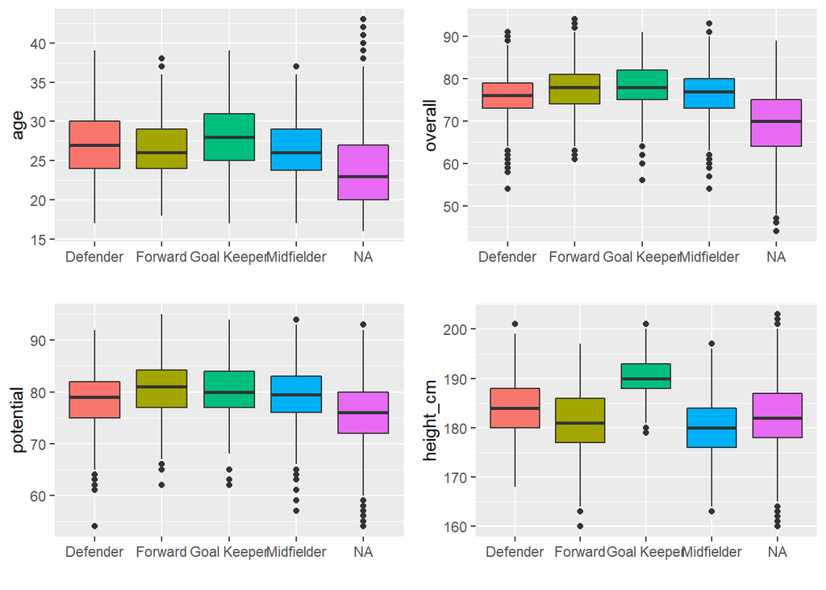

```r
gp1 <- ggplot(fifa, aes(x=team_position.Class, y=age, fill=team_position.Class)) + geom_boxplot() + theme(legend.position="none") + xlab("")
gp2 <- ggplot(fifa, aes(x=team_position.Class, y=overall, fill=team_position.Class)) + geom_boxplot() + theme(legend.position="none") + xlab("")
gp3 <- ggplot(fifa, aes(x=team_position.Class, y=potential, fill=team_position.Class)) + geom_boxplot() + theme(legend.position="none") + xlab("")
gp4 <- ggplot(fifa, aes(x=team_position.Class, y=height_cm, fill=team_position.Class)) + geom_boxplot() + theme(legend.position="none") + xlab("")
gp5 <- ggplot(fifa, aes(x=team_position.Class, y=weight_kg, fill=team_position.Class)) + geom_boxplot() + theme(legend.position="none") + xlab("")
gp6 <- ggplot(fifa, aes(x=team_position.Class, y=value_eur, fill=team_position.Class)) + geom_boxplot() + theme(legend.position="none") + xlab("")
gp7 <- ggplot(fifa, aes(x=team_position.Class, y=wage_eur, fill=team_position.Class)) + geom_boxplot() + theme(legend.position="none") + xlab("")

grid.arrange(gp1, gp2, gp3, gp4, ncol = 2)
```

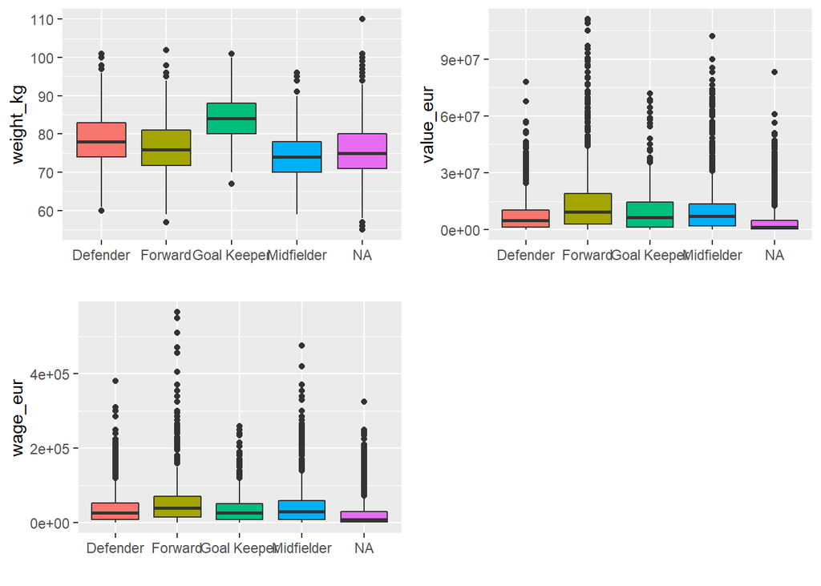

```r
grid.arrange(gp5, gp6, gp7, ncol = 2)
```

```r
# Limpiamos memoria
rm(gp1, gp2, gp3, gp4, gp5, gp6, gp7)

#table(boxplot.stats(fifa$value_eur)$out)
```

## 2.3 Correlacion

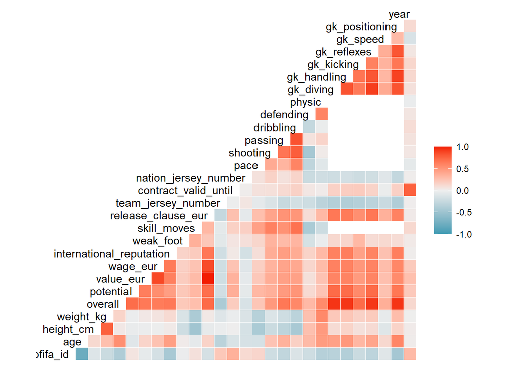

```r
fifa.var_cuanti <- unlist(lapply(fifa, is.numeric))
ggcorr(fifa[fifa.var_cuanti], label = FALSE, label_size = 2.9, hjust = 1, layout.exp = 2)
```

## 2.4 Más limpieza

```r
# Eliminamos los datos que tengan vacíos alguno de los dos campos objetivo
fifa <- fifa %>% filter(value_eur != 0)
fifa <- fifa %>% filter(!is.na(value_eur))
fifa <- fifa %>% filter(team_position.Class != "NA")
table(fifa$team_position.Class)
```

```
##
##    Defender     Forward Goal Keeper  Midfielder
##        1398         694         352        1405
```

Las varibles que albergan las métricas que definen el rendimiento del jugador en el juego están acompañadas por un valor fijo y una cantidad variable que se suma a éste, para representar la evolución del jugador durante algunos modos de juego. Para este análisis nos quedaremos con la parte fija.

```r
# Pasamos las métricas de rendimiento nuevas a numéricas

for(i in 45:104) {       # Iteramos sobre las métricas que queremos limpiar
  fifa[,i] <- as.numeric(substr(fifa[,i], 1, 2)) # Cogemos los dos primeros caracteres y a numeric
  # VALORES VACÍOS DE STAS VARIABLES POR LA MEDIANA DEL GRUPO (PORTEROS, DEFENSAS, MEDIOCENTROS, DELANTEROS)
}
```

PARA ROGER: He dejado una línea dentro del bucle para que sustituyas los valores vacíos de cada una de las 60 variables de habilidades extra por la mediana del valor de esa habilidad de los integrantes de su grupo. Por ejemplo, si Ter Stegen tiene el campo `rb` vacío, debe sustituirse por la mediana de los valores `rb` de los porteros. He intentado hacerlo yo pero no lo consigo. Además, para aplicar *PCA* sobre estas 60 variables es necesario haber imputado antes sus valores vacíos.

# 3 Análisis exploratorio de los datos (EDA)

Definimos esta función que se usará para representar varias gráficas en la misma celda con la librería `ggplot2`.

```r
# Multiple plot function
#
# ggplot objects can be passed in ..., or to plotlist (as a list of ggplot objects)
# - cols:   Number of columns in layout
# - layout: A matrix specifying the layout. If present, 'cols' is ignored.
#
# If the layout is something like matrix(c(1,2,3,3), nrow=2, byrow=TRUE),
# then plot 1 will go in the upper left, 2 will go in the upper right, and
# 3 will go all the way across the bottom.
#
multiplot <- function(..., plotlist=NULL, file, cols=1, layout=NULL) {
  library(grid)

  # Make a list from the ... arguments and plotlist
  plots <- c(list(...), plotlist)

  numPlots = length(plots)

  # If layout is NULL, then use 'cols' to determine layout
  if (is.null(layout)) {
    # Make the panel
    # ncol: Number of columns of plots
    # nrow: Number of rows needed, calculated from # of cols
    layout <- matrix(seq(1, cols * ceiling(numPlots/cols)),
                    ncol = cols, nrow = ceiling(numPlots/cols))
  }

 if (numPlots==1) {
    print(plots[[1]])

  } else {
    # Set up the page
    grid.newpage()
    pushViewport(viewport(layout = grid.layout(nrow(layout), ncol(layout))))

    # Make each plot, in the correct location
    for (i in 1:numPlots) {
      # Get the i,j matrix positions of the regions that contain this subplot
      matchidx <- as.data.frame(which(layout == i, arr.ind = TRUE))

      print(plots[[i]], vp = viewport(layout.pos.row = matchidx$row,
                                      layout.pos.col = matchidx$col))
    }
  }
}
```

## 3.1 Datos de partida

Los datos de partida en el EDA se encuentran en el *dataset* `fifa` resultado del proceso previo de limpieza realizado por Roger.

```r
# Visualizamos los datos de partida para el EDA
my.head(fifa)
```

| team_position | sofifa_id | player_url | short_name | long_name | age | dob | height_cm | weight_kg | nationality | club | overall | potential | value_eur | wage_eur | player_positions | preferred_foot | international_reputation | weak_foot | skill_moves | work_rate | body_type | real_face | release_clause_eur | player_tags | team_jersey_number | loaned_from | joined | contract_valid_until | nation_position | … |
| --- | --- | --- | --- | --- | --- | --- | --- | --- | --- | --- | --- | --- | --- | --- | --- | --- | --- | --- | --- | --- | --- | --- | --- | --- | --- | --- | --- | --- | --- | --- |
| CAM | 222148 | https://sofifa.com/player/222148/ondrej-duda/20/159586 | O. Duda | Ondrej Duda | 24 | 1994-12-05 | 181 | 75 | Slovakia | Hertha BSC | 77 | 83 | 1.2e+07 | 25000 | CAM, CM | Right | 1 | 4 | 4 | Medium/High | Lean | Yes | 22800000 |  | 10 |  | 2016-07-20 | 2023 |  | … |
| CAM | 146937 | https://sofifa.com/player/146937/mikel-arruabarrena/16/158127 | Arruabarrena | Mikel Arruabarrena Aranbide | 32 | 1983-02-09 | 189 | 80 | Spain | SD Eibar | 71 | 71 | 1.3e+06 | 15000 | CAM, ST | Right | 1 | 3 | 3 | High/Medium | Lean | No | NA |  | 10 |  | 2008-06-23 | 2016 |  | … |
| CAM | 201313 | https://sofifa.com/player/201313/camillo-ciano/20/159586 | C. Ciano | Camillo Ciano | 29 | 1990-02-22 | 176 | 73 | Italy | Frosinone | 74 | 74 | 5.5e+06 | 5000 | ST, CAM, CF | Left | 1 | 4 | 4 | Medium/Medium | Normal | No | 8800000 |  | 28 |  | 2017-07-10 | 2021 |  | … |
| CAM | 208128 | https://sofifa.com/player/208128/hakan-calhanoglu/17/158492 | H. ÇalhanoÄŸlu | Hakan ÇalhanoÄŸlu | 22 | 1994-02-08 | 178 | 76 | Turkey | Bayer 04 Leverkusen | 80 | 84 | 1.9e+07 | 70000 | CAM, LM, CM | Right | 3 | 5 | 4 | Medium/Medium | Lean | Yes | NA | #Distance Shooter, #FK Specialist | 10 |  | 2014-07-04 | 2019 | RM | … |
| CAM | 210724 | https://sofifa.com/player/210724/callum-paterson/20/159586 | C. Paterson | Callum Paterson | 24 | 1994-10-13 | 187 | 76 | Scotland | Cardiff City | 73 | 77 | 5.5e+06 | 22000 | ST, CM, RB | Right | 1 | 3 | 3 | High/High | Normal | Yes | 10900000 | #Engine | 13 |  | 2017-07-01 | 2022 |  | … |
| CAM | 51100 | https://sofifa.com/player/51100/stefano-mauri/16/158127 | S. Mauri | Stefano Mauri | 35 | 1980-01-08 | 184 | 79 | Italy | Lazio | 80 | 80 | 5.5e+06 | 70000 | CAM, LW, CM | Left | 2 | 4 | 3 | High/Medium | Lean | No | NA | #Acrobat | 6 |  | 2015-08-22 | 2016 |  | … |

Una vez planteados los objetivos analíticos, el primer paso del análisis exploratorio es estudiar la distribución de las variables predictoras y su dependencia con las variables a predecir. También resulta interesante observar la correlación entre variables predictoras.

## 3.2 Variables objetivo

Las variables objetivo de este análisis son:

- El valor de mercado de los jugadores en euros: `value_eur`.
- La posición de los jugadores en el terreno de juego: `team_position.Class`.

Representamos a continuación las distribuciones de ambas magnitudes:

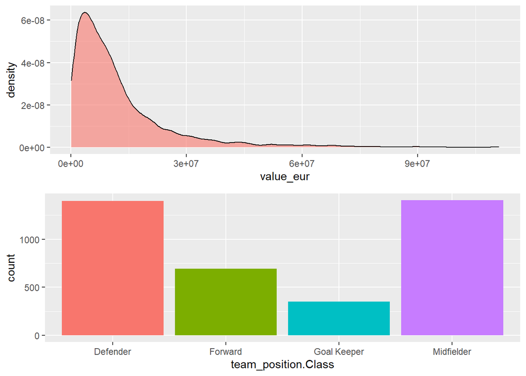

```r
h1 <- ggplot(fifa, aes(x = value_eur, fill = "red")) + geom_density(alpha = 0.6) + theme(legend.position = "none")
h2 <- ggplot(fifa, aes(x = team_position.Class, fill = team_position.Class)) + geom_bar() + theme(legend.position = "none")

multiplot(h1, h2, cols=1)
```

La distribución del valor de mercado sigue una ley de distribución *Gamma* a simple vista.

```r
library(fitdistrplus)
# En lugar de ajustar los valores en euros lo haremos en millones de euros:
x.gamma <- fifa$value_eur/10e6
fit.gamma <- fitdist(x.gamma, distr = "gamma")
summary(fit.gamma)
```

```
## Fitting of the distribution ' gamma ' by maximum likelihood
## Parameters :
##        estimate Std. Error
## shape 1.1139395 0.02256892
## rate  0.8889181 0.02255325
## Loglikelihood:  -4703.721   AIC:  9411.443   BIC:  9423.954
## Correlation matrix:
##           shape      rate
## shape 1.0000000 0.7985475
## rate  0.7985475 1.0000000
```

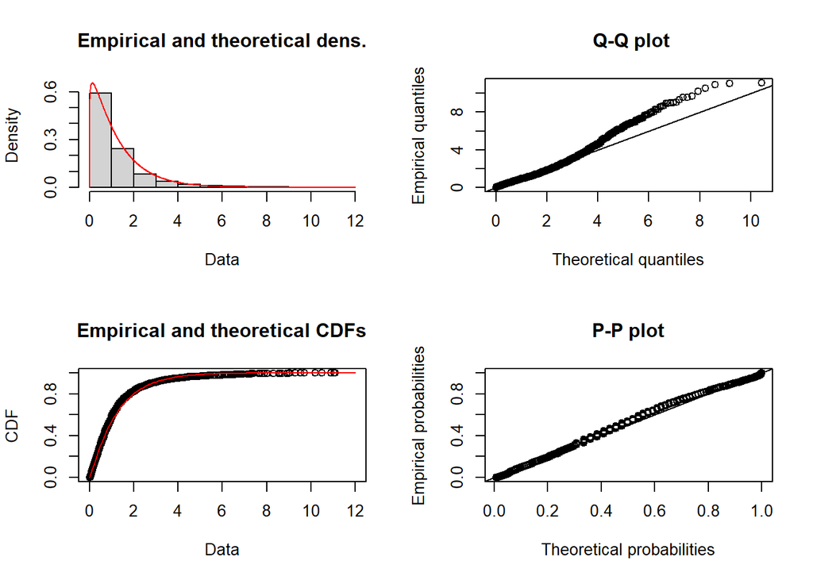

```r
plot(fit.gamma)
```

(Los resultados de los ajustes los comentaremos en el documento PDF)

Influencia de la posición del jugador en el valor de mercado:

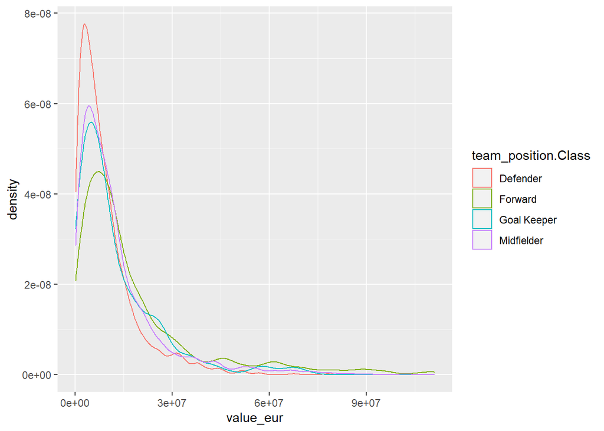

```r
ggplot(fifa, aes(x = value_eur, colour = team_position.Class)) + geom_density()
```

Parece existir una ligera influencia de la posición del jugador en valor de mercado. Si observamos la posición de los picos y la altura de la falda derecha de las distribuciones, nos daremos cuenta de que los delanteros tienden a ser más caros que los defensas.

## 3.3 Edad, peso y altura

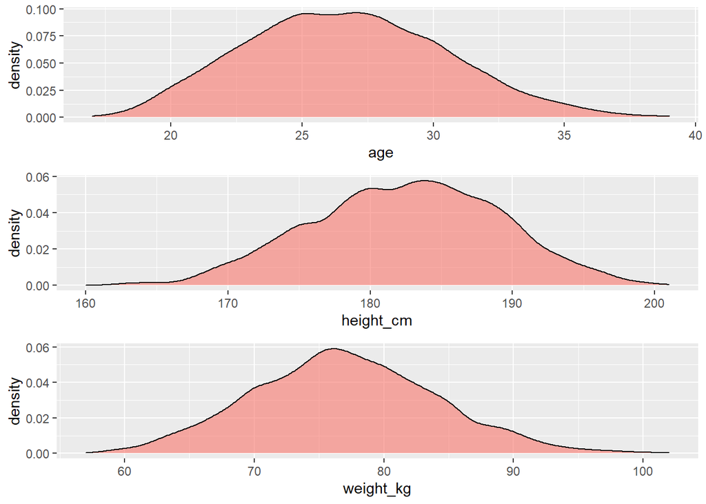

```r
h1 <- ggplot(fifa, aes(x = age, fill = "red")) + geom_density(alpha = 0.6) + theme(legend.position = "none")
h2 <- ggplot(fifa, aes(x = height_cm, fill = "red")) + geom_density(alpha = 0.6) + theme(legend.position = "none")
h3 <- ggplot(fifa, aes(x = weight_kg, fill = "red")) + geom_density(alpha = 0.6) + theme(legend.position = "none")

multiplot(h1, h2, h3, cols=1)
```

Podemos observar si existe dependencia entre estas variables y la posición del jugador:

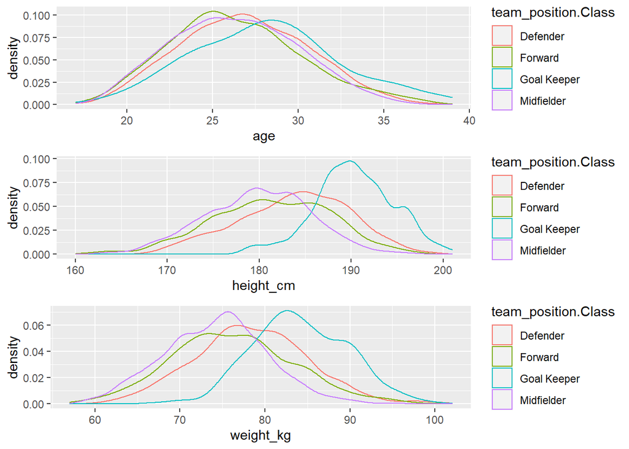

```r
h1 <- ggplot(fifa, aes(x = age, colour = team_position.Class)) + geom_density()
h2 <- ggplot(fifa, aes(x = height_cm, colour = team_position.Class)) + geom_density()
h3 <- ggplot(fifa, aes(x = weight_kg, colour = team_position.Class)) + geom_density()

multiplot(h1, h2, h3, cols=1)
```

- Edad: no se aprecian diferencias muy acuciantes entre las edades de cada grupo. Aunque existe una ligera tendencia entre los porteros a tener mayor edad.
- Altura: en caso sí se observa que los porteros son signifcativamente más altos, y que los jugadores más bajos son los mediocentros.
- Peso: los porteros son significativamente más pesados.

En general, se observan diferencias entre las distribuciones de porteros, defensas, mediocentros y delanteros. Por tanto estas variables pueden resultar útiles para el análisis de la posición óptima de los jugadores.

Ahora vamos a ver la dependencia con la otra variable objetivo: el valor de mercado `value_eur`:

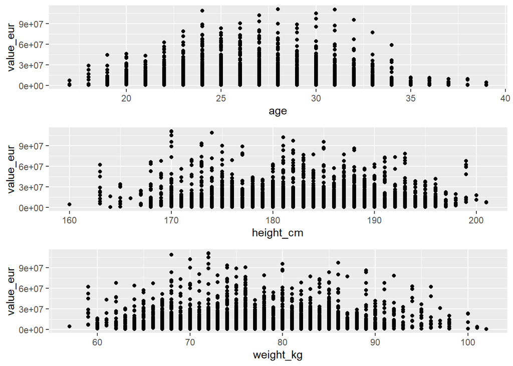

```r
h1 <- ggplot(fifa, aes(x=age, y=value_eur)) + geom_point()
h2 <- ggplot(fifa, aes(x=height_cm, y=value_eur)) + geom_point()
h3 <- ggplot(fifa, aes(x=weight_kg, y=value_eur)) + geom_point()

multiplot(h1, h2, h3, cols=1)
```

Como vemos, tanto el peso como la altura no parecen tener demasiada influencia en el valor del jugador. La edad tampoco tiene una influencia muy marcada, sin embargo si puede observarse una caída paulatina del precio cuando se superan los 32 años, también se puede ver que los jugadores jóvenes no llegan a su precio máximo hasta los 23. En la horquilla entre los 23 y los 32 años de edad el valor parece no tener una influencia grande.

Para terminar con esta terna de variables, podemos representar la correlación entre ellas y la correlación con el valor de mercado (al ser ésta una variable numérica):

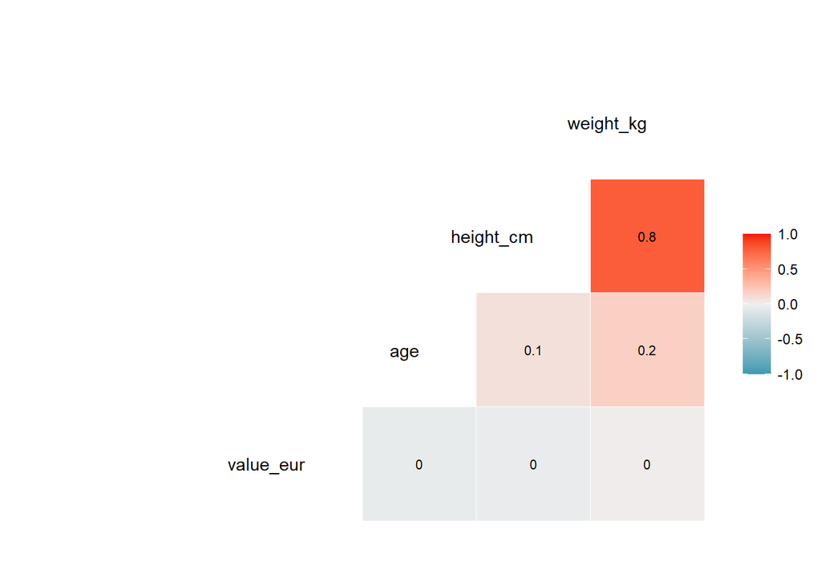

```r
ggcorr(fifa[c(14,6,8,9)], label = TRUE, label_size = 2.9, hjust = 1, layout.exp = 2)
```

Como era de esperar por los resultados gráficos obtenidos, la edad, el peso y la altura no son buenos predictores del valor de mercado, por lo tanto no se incluirán en el análisis de la predicción de éste. Algo que se esperaba es la estrecha correlación entre la altura y el peso. La altura y el peso son dos variables que pueden influir en la posición del jugador, como se ha observado en los gráficos, pero al estar tan estrechamente correlacionadas la mejor opción puede ser tomar una sola para el análisis de la posición.

## 3.4 Habilidades básicas

Las habilidades son las variables que más influencia se espera que tengan en la predicción tanto de la posición del jugador como de su valor de mercado.

En el juego un jugador está representado por 6 habilidades básicas. Que son `pace`,`shooting`, `passing`, `dribbling`, `defending` y `physical`.

[figure not shown]

player overview

Para hacer un análisis exploratorio más significativo y adaptado a nuestro objetivo, representaremos cada una de estas habilidades sobre cada una de las tres clases de posiciones: defensores (`Defender`), mediocampistas (`Midfielder`) y atacantes (`Forward`):

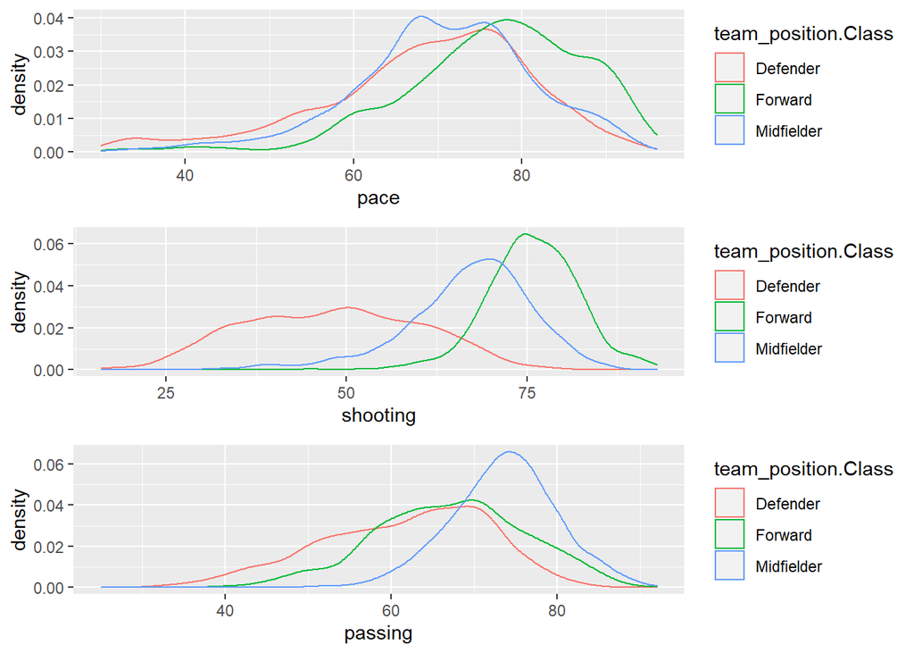

```r
library(ggplot2)

d1 <- ggplot(fifa, aes(x = pace, colour = team_position.Class)) + geom_density()
d2 <- ggplot(fifa, aes(x = shooting, colour = team_position.Class)) + geom_density()
d3 <- ggplot(fifa, aes(x = passing, colour = team_position.Class)) + geom_density()

multiplot(d1, d2, d3, cols=1)
```

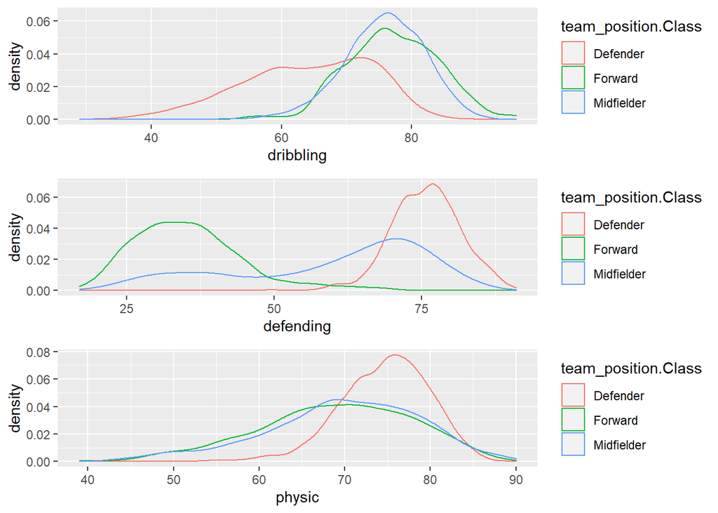

```r
d4 <- ggplot(fifa, aes(x = dribbling, colour = team_position.Class)) + geom_density()
d5 <- ggplot(fifa, aes(x = defending, colour = team_position.Class)) + geom_density()
d6 <- ggplot(fifa, aes(x = physic, colour = team_position.Class)) + geom_density()

multiplot(d4, d5, d6, cols=1)
```

Se puede observar la diferencia en las distribuciones entre cada una de las tres posiciones. A continuación se calcula la media de cada una de las distribuciones anteriores:

```r
pace <- c(mean(fifa$pace[fifa$team_position.Class == "Defender"]),
           mean(fifa$pace[fifa$team_position.Class == "Midfielder"]),
           mean(fifa$pace[fifa$team_position.Class == "Forward"]))

shooting <- c(mean(fifa$shooting[fifa$team_position.Class == "Defender"]),
           mean(fifa$shooting[fifa$team_position.Class == "Midfielder"]),
           mean(fifa$shooting[fifa$team_position.Class == "Forward"]))

passing <- c(mean(fifa$passing[fifa$team_position.Class == "Defender"]),
           mean(fifa$passing[fifa$team_position.Class == "Midfielder"]),
           mean(fifa$passing[fifa$team_position.Class == "Forward"]))

dribbling <- c(mean(fifa$dribbling[fifa$team_position.Class == "Defender"]),
           mean(fifa$dribbling[fifa$team_position.Class == "Midfielder"]),
           mean(fifa$dribbling[fifa$team_position.Class == "Forward"]))

defending <- c(mean(fifa$defending[fifa$team_position.Class == "Defender"]),
           mean(fifa$defending[fifa$team_position.Class == "Midfielder"]),
           mean(fifa$defending[fifa$team_position.Class == "Forward"]))

physic <- c(mean(fifa$physic[fifa$team_position.Class == "Defender"]),
           mean(fifa$physic[fifa$team_position.Class == "Midfielder"]),
           mean(fifa$physic[fifa$team_position.Class == "Forward"]))

positions <- c("Defender", "Midfielder", "Forward")

means <- data.frame(positions, pace, shooting, passing, dribbling, defending, physic)
my.head(means)
```

| positions | pace | shooting | passing | dribbling | defending | physic |
| --- | --- | --- | --- | --- | --- | --- |
| Defender | 68.53648 | 48.00501 | 61.53362 | 64.03290 | 75.69456 | 74.63591 |
| Midfielder | 70.60712 | 67.01139 | 73.54448 | 75.72384 | 59.53808 | 69.74164 |
| Forward | 76.78386 | 75.80115 | 67.14265 | 77.09222 | 35.46398 | 68.86311 |

Y las desviaciones estándar:

```r
pace <- c(sd(fifa$pace[fifa$team_position.Class == "Defender"]),
           sd(fifa$pace[fifa$team_position.Class == "Midfielder"]),
           sd(fifa$pace[fifa$team_position.Class == "Forward"]))

shooting <- c(sd(fifa$shooting[fifa$team_position.Class == "Defender"]),
           sd(fifa$shooting[fifa$team_position.Class == "Midfielder"]),
           sd(fifa$shooting[fifa$team_position.Class == "Forward"]))

passing <- c(sd(fifa$passing[fifa$team_position.Class == "Defender"]),
           sd(fifa$passing[fifa$team_position.Class == "Midfielder"]),
           sd(fifa$passing[fifa$team_position.Class == "Forward"]))

dribbling <- c(sd(fifa$dribbling[fifa$team_position.Class == "Defender"]),
           sd(fifa$dribbling[fifa$team_position.Class == "Midfielder"]),
           sd(fifa$dribbling[fifa$team_position.Class == "Forward"]))

defending <- c(sd(fifa$defending[fifa$team_position.Class == "Defender"]),
           sd(fifa$defending[fifa$team_position.Class == "Midfielder"]),
           sd(fifa$defending[fifa$team_position.Class == "Forward"]))

physic <- c(sd(fifa$physic[fifa$team_position.Class == "Defender"]),
           sd(fifa$physic[fifa$team_position.Class == "Midfielder"]),
           sd(fifa$physic[fifa$team_position.Class == "Forward"]))

positions <- c("Defender", "Midfielder", "Forward")

sdevs <- data.frame(positions, pace, shooting, passing, dribbling, defending, physic)
my.head(sdevs)
```

| positions | pace | shooting | passing | dribbling | defending | physic |
| --- | --- | --- | --- | --- | --- | --- |
| Defender | 12.65295 | 12.160728 | 10.116074 | 10.108803 | 5.929952 | 5.333252 |
| Midfielder | 10.74554 | 8.798303 | 6.497341 | 6.252569 | 16.463229 | 8.999336 |
| Forward | 10.84534 | 6.343983 | 9.024008 | 7.018641 | 9.449387 | 8.946530 |

En la tabla de medias podemos apreciar en forma numérica las diferencias que se visualizaban en las gráficas anteriores. Podemos concluir que las seis habilidades básicas son buenas predictoras de la posición del jugador y por tanto deben estar presentes en el modelo de clasificación.

En cuanto a la dependencia de éstas con el valor de mercado del jugador:

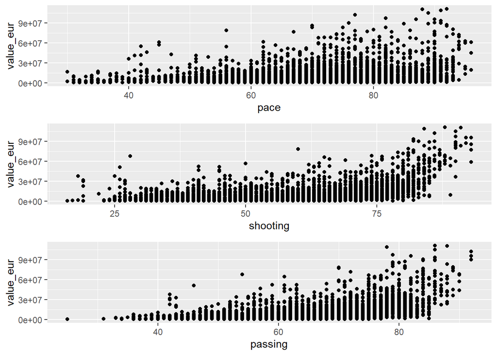

```r
h1 <- ggplot(fifa, aes(x=pace, y=value_eur)) + geom_point()
h2 <- ggplot(fifa, aes(x=shooting, y=value_eur)) + geom_point()
h3 <- ggplot(fifa, aes(x=passing, y=value_eur)) + geom_point()

multiplot(h1, h2, h3, cols=1)
```

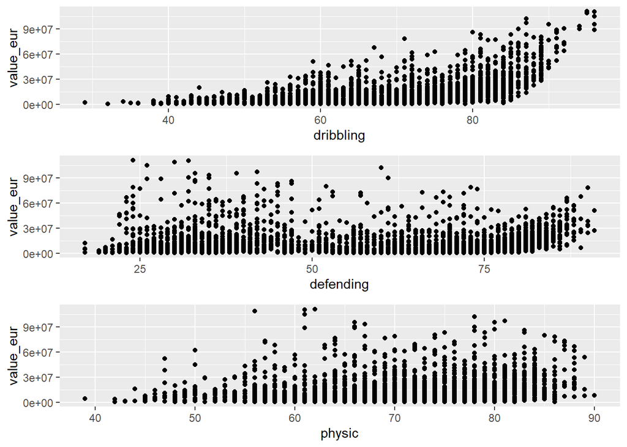

```r
h1 <- ggplot(fifa, aes(x=dribbling, y=value_eur)) + geom_point()
h2 <- ggplot(fifa, aes(x=defending, y=value_eur)) + geom_point()
h3 <- ggplot(fifa, aes(x=physic, y=value_eur)) + geom_point()

multiplot(h1, h2, h3, cols=1)
```

Observamos cierta relación entre cada una de las habilidades y el valor del jugador. Especialmente en las habilidades de atacante, que suelen ser los jugadores más cotizados. Sin embargo la correlación no es todo lo clara que podría esperarse, hay variables donde ni siquiera se observa relación alguna. Esto ocurre porque una habilidad por sí sola no hace a un jugador más caro o barato, si no el conjunto de ellas.

Para observar este fenómenos representaremos el `overall rating` y el `potential` en función del valor de mercado:

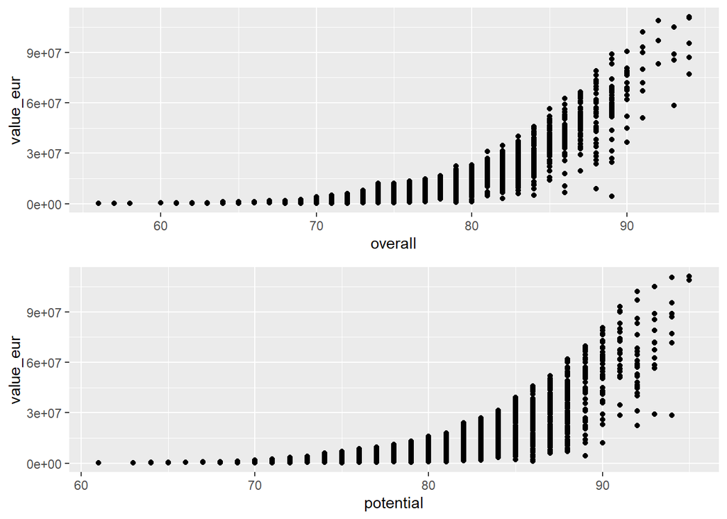

```r
h1 <- ggplot(fifa, aes(x=overall, y=value_eur)) + geom_point()
h2 <- ggplot(fifa, aes(x=potential, y=value_eur)) + geom_point()

multiplot(h1, h2, cols = 1)
```

Para cuantificar todas estas dependencias, calculamos los coeficientes de correlación entre cada una de las habilidades y el valor de mercado, incluyendo el `overall`:

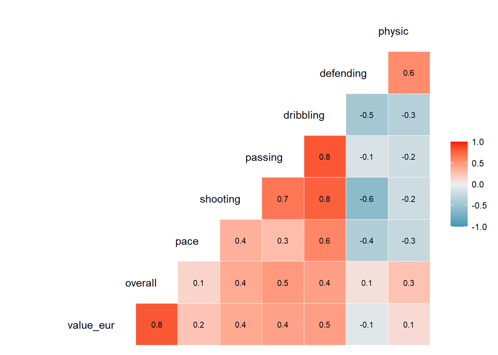

```r
ggcorr(fifa[c(14,11,12,32,33,34,35,36,37)], label = TRUE, label_size = 2.9, hjust = 1, layout.exp = 2)
```

Vemos la fuerte dependencia entre el `overall` y el valor de mercado. Dados estos resultados, para el estudio del valor de mercado se usaría el `overall` y las variables `pace`, `shooting`, `passing` y `dribbling`. Se excluirían del análisis `defending` y `physic` por presentar una correlación con la variable objetivo menor a 0.2. Por otra parte, hay que tener en cuenta que estamos analizando en el mismo conjunto a los delanteros y a los defensas y mediocentros. ¿Cambiarían estos coeficientes si los representamos por separado para cada posición?

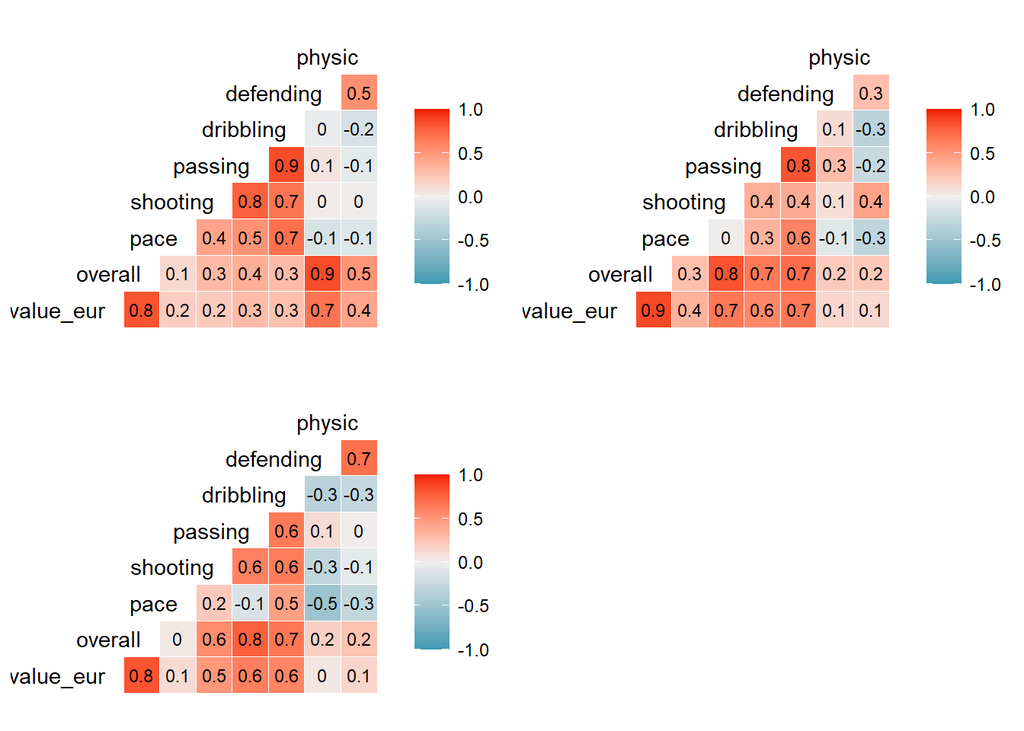

```r
fifa.def <- fifa %>% filter(team_position.Class == "Defender")
fifa.mid <- fifa %>% filter(team_position.Class == "Midfielder")
fifa.for <- fifa %>% filter(team_position.Class == "Forward")

h1 <- ggcorr(fifa.def[c(14,11,12,32,33,34,35,36,37)], label = TRUE, label_size = 3, hjust = 1, layout.exp = 2)
h2 <- ggcorr(fifa.mid[c(14,11,12,32,33,34,35,36,37)], label = TRUE, label_size = 3, hjust = 1, layout.exp = 2)
h3 <- ggcorr(fifa.for[c(14,11,12,32,33,34,35,36,37)], label = TRUE, label_size = 3, hjust = 1, layout.exp = 2)

multiplot(h1, h2, h3, cols = 2)
```

Vemos como las habilidades que son importantes para el valor en los defensas (`defending` y `physic`), no lo son para los delanteros, y viceversa. Entonces, ¿qué variables seleccionamos para el análisis?

Recordamos que tenemos dos objetivos analíticos:

- Predecir el valor de mercado mediante regresión.
- Clasificar cada jugador en su posición óptima.

El valor de mercado depende de la posición (y de otras variables) pero la posición no depende del valor de mercado. Entonces a la hora de construir nuestro *pipeline*, lo correcto es colocar el clasificador en primera línea y aplicar la regresión por separado a defensas, mediocentros y delanteros, así podremos seleccionar las mejores variables predictoras en cada caso.

En resumen, en lugar de realizar la regresión sobre el conjunto total de jugadores y dejar en manos de un algoritmo la selección de las variables predictoras más importantes, aprovechamos que conocemos de antemano las variables más determinantes para cada posición y aplicamos la regresión por separado personalizando más el análisis a cada tipo de jugador.

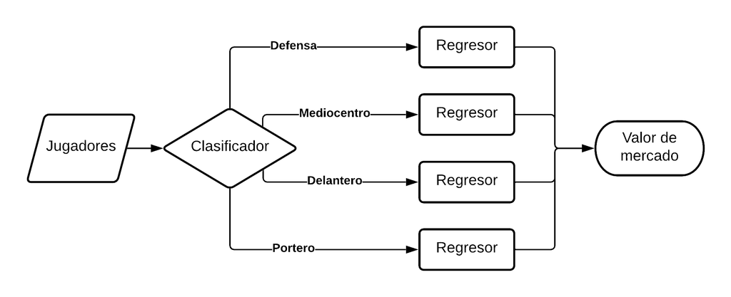

fifa pipeline

## 3.5 Habilidades extra

Si observamos el *dataset* podemos ver que estas seis no son las únicas variables que el juego utiliza para caracterizar a cada jugador. Existe una larga lista de variables adicionales, unas 60. Sin embargo, para evitar saturar el problema de regresión, intentaremos reducir esas 60 variables a 5 mediante métodos de reducción de la dimensionalidad como *PCA*.